# SPY Short Strangle — Backtesting Notebook

```python
def attempt_defensive_leg_roll(
    trade, eval_date, S_d, vix_d, r_d, dte_rem, T_d, data, engine, params
) -> bool:
    """Check trigger and execute a defensive leg roll if conditions are met.

    When the tested side's |delta| breaches defensive_trigger_delta (default 0.30),
    the UNTESTED (profitable) side is bought back and a new leg is sold at
    leg_roll_target_delta, collecting additional credit and flattening delta.
    The tested side stays in place.

    Returns True if a roll fired (caller must re-read active strikes and
    recompute mid_d for this iteration). Returns False if no roll.
    """
    if not params.get("defensive_leg_roll_enabled", False):
        return False
    if len(trade.leg_rolls) >= params.get("max_leg_rolls_per_trade", 2):
        return False

    trigger_delta = params.get("defensive_trigger_delta", 0.30)
    target_delta = params.get("leg_roll_target_delta", 0.16)
    o_adj = params["open_fill_adj"]
    c_adj = params["close_fill_adj"]
    comm = params["commission_per_leg"]
    _real = getattr(engine, "uses_real_fills", False)
    eff_o_adj = 0.0 if _real else o_adj
    eff_c_adj = 0.0 if _real else c_adj

    # Read current per-leg deltas
    put_delta = engine.get_daily_delta(
        trade.active_put_strike,
        S_d,
        dte_rem,
        vix_d,
        r_d,
        "put",
        eval_date=eval_date,
        expiration=trade.expiration,
    )
    call_delta = engine.get_daily_delta(
        trade.active_call_strike,
        S_d,
        dte_rem,
        vix_d,
        r_d,
        "call",
        eval_date=eval_date,
        expiration=trade.expiration,
    )

    # Determine which side (if any) is tested
    tested_side = None
    trigger_d = None
    if abs(put_delta) >= trigger_delta:
        tested_side = "put"
        trigger_d = abs(put_delta)
    elif abs(call_delta) >= trigger_delta:
        tested_side = "call"
        trigger_d = abs(call_delta)

    if tested_side is None:
        return False

    # Roll the UNTESTED side (the profitable one)
    untested_side = "call" if tested_side == "put" else "put"
    untested_old_strike = (
        trade.active_call_strike if untested_side == "call" else trade.active_put_strike
    )

    # Cost to buy back old untested leg (ask fill)
    close_mark = engine.get_leg_mark(
        untested_old_strike,
        S_d,
        dte_rem,
        vix_d,
        r_d,
        untested_side,
        eval_date=eval_date,
        expiration=trade.expiration,
    )
    close_cost_ps = close_mark * (1.0 + eff_c_adj)

    # Find new untested leg at target_delta (closer to ATM)
    new_strike, new_open_mark = engine.find_strike_at_delta(
        S_d,
        T_d,
        r_d,
        vix_d,
        target_delta,
        untested_side,
        eval_date=eval_date,
        expiration=trade.expiration,
    )

    # Sanity: new strike must move toward ATM vs old strike
    if untested_side == "put" and new_strike <= untested_old_strike:
        return False
    if untested_side == "call" and new_strike >= untested_old_strike:
        return False

    new_credit_ps = new_open_mark * (1.0 + eff_o_adj)

    # Net credit must be positive (roll for credit only)
    net_credit_dollar = (new_credit_ps - close_cost_ps) * 100.0 - 2.0 * comm
    if net_credit_dollar <= 0:
        return False

    # ── Execute: record event, update trade state ────────────────────────
    event = LegRollEvent(
        event_date=eval_date,
        side=untested_side,
        old_strike=untested_old_strike,
        new_strike=new_strike,
        close_cost_ps=close_cost_ps,
        new_credit_ps=new_credit_ps,
        net_credit_dollar=net_credit_dollar,
        trigger_delta=trigger_d,
    )
    trade.leg_rolls.append(event)

    if untested_side == "put":
        trade.current_put_strike = new_strike
    else:
        trade.current_call_strike = new_strike

    # Add roll credit to net_credit so profit-target % references cumulative premium
    trade.net_credit += net_credit_dollar

    # Recompute baseline mid: tested-side mark + new untested mark
    tested_old_strike = (
        trade.active_put_strike if tested_side == "put" else trade.active_call_strike
    )
    tested_mark = engine.get_leg_mark(
        tested_old_strike,
        S_d,
        dte_rem,
        vix_d,
        r_d,
        tested_side,
        eval_date=eval_date,
        expiration=trade.expiration,
    )
    trade.current_baseline_mid = tested_mark + new_open_mark

    return True


def evaluate_trade(
    trade: "Trade",
    data: pd.DataFrame,
    engine,
    params: dict,
    balance: float,
) -> tuple:
    """Run the daily eval loop for a single open trade.

    Iterates from the trade's entry_date to its expiration, checking exit
    conditions each day. On exit, sets trade.exit_*, trade.pnl, trade.pnl_pct.

    Return signature: (closed_trade, new_trade_or_None, new_balance)
      - new_trade_or_None is None for normal exits (PROFIT / STOP / 21DTE / EXPIRY).
      - When a roll succeeds, new_trade_or_None is the follow-on Trade (trade_num=None;
        caller assigns trade_num and links child_trade_num before continuing).

    All params are read from the params dict explicitly -- no closure.
    """
    r_default = params.get("risk_free_rate", 0.045)
    prof = params["profit_target_pct"]
    stop = params["stop_loss_pct"]
    manage_at_dte = params["manage_at_dte"]
    o_adj = params["open_fill_adj"]
    c_adj = params["close_fill_adj"]
    comm = params["commission_per_leg"]
    _real = getattr(engine, "uses_real_fills", False)
    eff_o_adj = 0.0 if _real else o_adj
    eff_c_adj = 0.0 if _real else c_adj
    use_price_stop = params.get("use_price_stop", False)
    roll_for_credit = params.get("roll_for_credit", False)
    max_rolls = params.get("max_rolls", 3)
    ov_orderly = params.get("overshoot_orderly", 0.25)
    ov_normal = params.get("overshoot_normal", 0.50)
    ov_violent = params.get("overshoot_violent", 0.80)
    rng_orderly = params.get("range_threshold_orderly", 0.015)
    rng_violent = params.get("range_threshold_violent", 0.030)
```

```python
    # NOTE: net_credit is read as trade.net_credit each time — not captured as a
    # local — because attempt_defensive_leg_roll mutates trade.net_credit in place
    # when a leg roll fires.  A stale local would discard collected leg roll credit.
    # put_k / call_k are similarly NOT cached; use trade.active_put/call_strike.
    expiration = trade.expiration

    exited = False
    for eval_date in data.loc[trade.entry_date : expiration].index[1:]:
        row_d = data.loc[eval_date]
        S_d = float(row_d["spy_close"])
        vix_d = float(row_d["vix_close"])
        r_d = float(row_d.get("risk_free_rate", r_default))
        trade.max_vix = max(trade.max_vix, vix_d)
        dte_rem = (expiration - eval_date).days
        T_d = max(dte_rem / 365.0, 1e-7)

        # Defensive leg roll: check trigger and execute if conditions met.
        # When a roll fires, active strikes are updated on the trade object.
        # The mid_d computation below automatically reads the new strikes.
        attempt_defensive_leg_roll(
            trade, eval_date, S_d, vix_d, r_d, dte_rem, T_d, data, engine, params
        )

        mid_d = engine.get_daily_mark(
            trade.active_put_strike,  # may differ from put_k after a leg roll
            trade.active_call_strike,  # may differ from call_k after a leg roll
            S_d,
            dte_rem,
            vix_d,
            r_d,
            eval_date=eval_date,
            expiration=expiration,
        )

        close_cost = mid_d * (1.0 + eff_c_adj) * 100.0 + 2.0 * comm
        pnl = trade.net_credit - close_cost
        pnl_pct = pnl / trade.net_credit

        # Record today's MTM value for the Sharpe calculation.
        # pnl here is the net P&L if we closed at today's mark — exactly
        # what we want. This is appended before any exit logic so the final
        # (exit) day captures the realized fill, not the trigger mark.
        trade.daily_marks.append((eval_date, pnl))

        # ── Profit target ────────────────────────────────────────────────────
        # Trigger:  raw mid-to-mid decay  (mid_d / entry_mid <= 50%)
        # Fill:     fill-adjusted close_cost  (mid * (1+eff_c_adj) + commissions)
        # After a leg roll, active_baseline_mid reflects the new combined mid.
        entry_mid_ps = trade.active_baseline_mid
        mid_pct = mid_d / entry_mid_ps

        exit_type = None

        # ── Price stop (optional -- canonical tastytrade rules have no price stop) ──
        if use_price_stop and pnl_pct <= -stop:
            exit_type = "STOP"
            # Overshoot blend in mid space (no fill adj, no commission).
            entry_mid_total = (trade.put_mid_ps + trade.call_mid_ps) * 100.0
            eod_mid_dollar = mid_d * 100.0
            mid_pnl_raw = entry_mid_total - eod_mid_dollar
            stop_loss_dollar_mid = -stop * entry_mid_total

            prev_idx = data.index.get_loc(eval_date)
            spy_hi = float(row_d.get("spy_high", S_d))
            spy_lo = float(row_d.get("spy_low", S_d))
            spy_prev_close = (
                float(data.iloc[prev_idx - 1]["spy_close"]) if prev_idx > 0 else S_d
            )
            daily_range_pct = (
                (spy_hi - spy_lo) / spy_prev_close if spy_prev_close > 0 else 0.0
            )

            spy_open = float(row_d.get("spy_open", S_d))
            vix_prev_raw = (
                float(data.iloc[prev_idx - 1]["vix_close"]) / 100.0
                if prev_idx > 0
                else vix_d / 100.0
            )
            gap_pct = (
                abs(spy_open - spy_prev_close) / spy_prev_close
                if spy_prev_close > 0
                else 0.0
            )

            r_open = float(row_d.get("risk_free_rate", r_default))
            open_mid = engine.get_gap_open_mark(
                spy_open,
                vix_prev_raw,
                gap_pct,
                trade.active_put_strike,
                trade.active_call_strike,
                T_d,
                r_open,
            )

            open_mid_dollar = open_mid * 100.0
            open_mid_pnl_raw = entry_mid_total - open_mid_dollar
            open_pnl_pct_mid = open_mid_pnl_raw / entry_mid_total

            if open_pnl_pct_mid <= -stop:
                overshoot_frac = 1.0
                regime = "GAP"
                reference_loss = open_mid_pnl_raw
                close_mid_for_slip = open_mid_dollar
            elif daily_range_pct >= rng_violent:
                overshoot_frac = ov_violent
                regime = "VIOLENT"
                reference_loss = mid_pnl_raw
                close_mid_for_slip = eod_mid_dollar
            elif daily_range_pct >= rng_orderly:
                overshoot_frac = ov_normal
                regime = "NORMAL"
                reference_loss = mid_pnl_raw
                close_mid_for_slip = eod_mid_dollar
            else:
                overshoot_frac = ov_orderly
                regime = "ORDERLY"
                reference_loss = mid_pnl_raw
                close_mid_for_slip = eod_mid_dollar

            fill_pnl_mid = stop_loss_dollar_mid + overshoot_frac * (
                reference_loss - stop_loss_dollar_mid
            )
            rt_cost = (
                entry_mid_total * abs(eff_o_adj)
                + close_mid_for_slip * eff_c_adj
                + 4.0 * comm
            )
            pnl = fill_pnl_mid - rt_cost
            pnl_pct = pnl / trade.net_credit
            trade.stop_regime = regime
            trade.overshoot_used = overshoot_frac

        elif mid_pct <= (1.0 - prof) and pnl > 0:
            # Guard pnl > 0: after a leg roll active_baseline_mid is reset to
            # the elevated vol-spike mark, so "50% of new baseline" can exceed
            # the cumulative credit collected. Without leg rolls this guard is
            # always satisfied (mid_pct<=0.5 implies pnl>0 for any realistic credit).
            exit_type = "PROFIT"

        elif dte_rem <= manage_at_dte:
            # ── 21-DTE management: attempt roll-for-credit or close flat ────
            if roll_for_credit and trade.roll_count < max_rolls:
                # Use roll_dte_max (default 60): at 21 DTE the next monthly
                # 3rd Friday is ~49 days out, past the entry dte_max of 45.
                _roll_dte_max = params.get("roll_dte_max", 60)
                new_exp = get_monthly_expiration(
                    eval_date, params["dte_min"], _roll_dte_max
                )
                if new_exp is not None:
                    # Cost to close current strangle
                    close_cost_old = mid_d * (1.0 + eff_c_adj) * 100.0 + 2.0 * comm
                    old_pnl = trade.net_credit - close_cost_old
```

```python
                    # Price the new strangle.
                    # The roll target may be 49–56 DTE — outside entry dte_max=45 but
                    # inside roll_dte_max=60. This is intentional: strike selection is
                    # delta-based (not DTE-based), so the DB query (date, expiration,
                    # opt, target_delta) is valid. Strikes will be slightly wider than
                    # a standard ~45 DTE entry because vol × √T is larger at longer
                    # DTE. Do not 'fix' this by clamping to dte_max=45 — there is no
                    # qualifying expiration that close to roll date.
                    T_new = (new_exp - eval_date).days / 365.0
                    (new_put_k, new_call_k, new_put_mid, new_call_mid, _new_used_db) = (
                        engine.get_entry_marks(
                            S_d,
                            T_new,
                            r_d,
                            vix_d,
                            entry_date=eval_date,
                            expiration=new_exp,
                        )
                    )
                    new_net_credit = (
                        new_put_mid * (1 + eff_o_adj) + new_call_mid * (1 + eff_o_adj)
                    ) * 100.0 - 2.0 * comm

                    roll_credit_val = new_net_credit - close_cost_old

                    if roll_credit_val > 0 and new_net_credit > 0:
                        # Roll succeeds -- close old, open new
                        trade.exit_date = eval_date
                        trade.exit_dte = dte_rem
                        trade.exit_type = "ROLLED"
                        trade.pnl = round(old_pnl, 2)
                        trade.pnl_pct = old_pnl / trade.net_credit
                        trade.roll_credit = roll_credit_val
                        balance += old_pnl

                        new_trade = Trade(
                            trade_num=None,  # assigned by run_backtest
                            entry_date=eval_date,
                            expiration=new_exp,
                            entry_dte=(new_exp - eval_date).days,
                            put_strike=new_put_k,
                            call_strike=new_call_k,
                            put_mid_ps=new_put_mid,
                            call_mid_ps=new_call_mid,
                            net_credit=new_net_credit,
                            entry_vix=vix_d,
                            used_market_data=_new_used_db,
                            parent_trade_num=trade.trade_num,
                            roll_count=trade.roll_count + 1,
                        )
                        new_trade.max_vix = vix_d
                        new_trade.daily_marks = [
                            (eval_date, 0.0)
                        ]  # entry seed for Sharpe MTM series
                        return trade, new_trade, balance
                    # roll_credit <= 0 or new_net_credit <= 0: fall through to 21DTE

            # Roll not attempted or failed -- close flat
            exit_type = "21DTE"

        if exit_type:
            trade.exit_date = eval_date
            trade.exit_dte = dte_rem
            trade.exit_type = exit_type
            trade.pnl = round(pnl, 2)
            trade.pnl_pct = pnl_pct
            balance += pnl
            exited = True
            break

    if not exited:
        last = data.index[data.index <= expiration][-1]
        S_e = float(data.loc[last, "spy_close"])
        intr = max(trade.active_put_strike - S_e, 0.0) + max(
            S_e - trade.active_call_strike, 0.0
        )
        cc = intr * (1.0 + eff_c_adj) * 100.0 + 2.0 * comm
        pnl = trade.net_credit - cc
        trade.exit_date = expiration
        trade.exit_dte = 0
        trade.exit_type = "EXPIRY"
        trade.pnl = round(pnl, 2)
        trade.pnl_pct = pnl / trade.net_credit
        balance += pnl

    return trade, None, balance


def run_backtest(data: pd.DataFrame, params: dict, engine=None):
    r_default = params.get("risk_free_rate", 0.045)
    if engine is None:
        engine = SyntheticEngine(params)
    o_adj = params["open_fill_adj"]
    _real = getattr(engine, "uses_real_fills", False)
    eff_o_adj = 0.0 if _real else o_adj
    comm = params["commission_per_leg"]
    balance = params["initial_balance"]
    single_position = params.get("single_position", True)
    # latest_open_exit tracks when the current chain finishes.
    # Used to skip new monthly entries while a prior position is open.
    latest_open_exit = pd.Timestamp.min

    trades: List[Trade] = []
    equity: dict = {}
    trade_num: int = 0
    skipped_entries: int = 0

    for entry_date in get_entry_dates(
        data,
        params["start_date"],
        params["end_date"],
        params["dte_min"],
        params["dte_max"],
    ):
        if entry_date not in data.index:
            continue
        if single_position and entry_date < latest_open_exit:
            skipped_entries += 1
            continue  # prior chain still open; skip this monthly entry
        row = data.loc[entry_date]
        S = float(row["spy_close"])
        vix = float(row["vix_close"])

        expiration = get_monthly_expiration(
            entry_date, params["dte_min"], params["dte_max"]
        )
        if expiration is None:
            continue
        entry_dte = (expiration - entry_date).days
        T = entry_dte / 365.0
        r = float(row.get("risk_free_rate", r_default))

        put_k, call_k, put_mid, cal_mid, _used_db = engine.get_entry_marks(
            S, T, r, vix, entry_date=entry_date, expiration=expiration
        )

        net_credit = (
            put_mid * (1 + eff_o_adj) + cal_mid * (1 + eff_o_adj)
        ) * 100.0 - 2.0 * comm
        if net_credit <= 0.0:
            continue

        trade_num += 1
        trade = Trade(
            trade_num=trade_num,
            entry_date=entry_date,
            expiration=expiration,
            entry_dte=entry_dte,
            put_strike=put_k,
            call_strike=call_k,
            put_mid_ps=put_mid,
            call_mid_ps=cal_mid,
            net_credit=net_credit,
            entry_vix=vix,
            used_market_data=_used_db,
        )
        trade.max_vix = vix  # initialised; updated daily in evaluate_trade
        trade.daily_marks = [(entry_date, 0.0)]  # entry day: MTM value = 0
```

```python
        # Iterative roll continuation -- follows the chain until a terminal exit
        active = trade
        while active is not None:
            closed, new_active, balance = evaluate_trade(
                active, data, engine, params, balance
            )
            equity[closed.exit_date] = round(balance, 2)
            trades.append(closed)
            if new_active is not None:
                trade_num += 1
                new_active.trade_num = trade_num
                closed.child_trade_num = trade_num
                active = new_active
            else:
                active = None
        # Chain complete: update barrier so next monthly entry waits
        # until this chain (including any rolls) has fully exited.
        latest_open_exit = closed.exit_date

    return trades, pd.Series(equity).sort_index(), skipped_entries
```

```python
# ── Market-mode date guardrail ───────────────────────────────────────────
# options_data covers 2008-01-02 -> 2025-12-12. Backtesting outside this
# window in market mode silently falls back to synthetic for every trade,
# making results misleading. Raise early instead.
_DB_FIRST = pd.Timestamp("2008-01-02")
_DB_LAST = pd.Timestamp("2025-12-12")

if PARAMS.get("mode") == "market":
    _start = pd.Timestamp(PARAMS["start_date"])
    _end = pd.Timestamp(PARAMS["end_date"])
    _errors = []
    if _start < _DB_FIRST:
        _errors.append(
            f"start_date {_start.date()} is before DB coverage ({_DB_FIRST.date()})"
        )
    if _end > _DB_LAST:
        _errors.append(
            f"end_date {_end.date()} is after DB coverage ({_DB_LAST.date()})"
        )
    if _errors:
        raise ValueError(
            "Market mode date range out of bounds:\n"
            + "\n".join(f"  - {e}" for e in _errors)
            + "\nSwitch to mode='synthetic' or adjust start_date / end_date."
        )

print("Running backtest...")
engine = make_engine(PARAMS)
trades, equity_curve, skipped_entries = run_backtest(data, PARAMS, engine)

final_balance = PARAMS["initial_balance"] + sum(t.pnl for t in trades)
total_return = (final_balance - PARAMS["initial_balance"]) / PARAMS["initial_balance"]

# ── SPY buy-and-hold benchmark ───────────────────────────────────────
# Note: spy_close is unadjusted (actual market price), so spy_total_return
# reflects price appreciation only -- dividends (~1.3%/yr) are excluded.
# The options P&L is not affected by this choice.
spy_window = data.loc[
    pd.Timestamp(PARAMS["start_date"]) : pd.Timestamp(PARAMS["end_date"]),
    "spy_close",
]
spy_start_price = float(spy_window.iloc[0])
spy_end_price = float(spy_window.iloc[-1])
spy_total_return = (spy_end_price - spy_start_price) / spy_start_price

# Normalise SPY to the same starting balance for equity-curve comparison
spy_equity = spy_window / spy_start_price * PARAMS["initial_balance"]

# SPY daily returns for Sharpe (excess of daily risk-free rate)
_spy_daily = spy_window.pct_change().dropna()
_spy_rf = data.loc[_spy_daily.index, "risk_free_rate"] / 252
spy_sharpe = float(
    ((_spy_daily - _spy_rf).mean() / _spy_daily.std(ddof=1)) * np.sqrt(252)
)

print(f"Trades executed : {len(trades)}")
print(f"Skipped entries (single-position): {skipped_entries}")
print(f'Initial balance : ${PARAMS["initial_balance"]:,.2f}')
print(f"Final balance   : ${final_balance:,.2f}")
print(f"Total P&L       : ${final_balance - PARAMS['initial_balance']:+,.2f}")
print(f"Total return    : {total_return*100:.1f}%")
print(
    f"SPY total return: {spy_total_return*100:.1f}%  (price only, excludes ~1.3%/yr dividends)"
)
print(f"SPY Sharpe      : {spy_sharpe:.2f}")
```

```
Running backtest...
MarketEngine: connected to data/Spy Options Database.db
Trades executed : 180
Skipped entries (single-position): 21
Initial balance : $50,000.00
Final balance   : $52,275.36
Total P&L       : $+2,275.36
Total return    : 4.6%
SPY total return: 419.0%  (price only, excludes ~1.3%/yr dividends)
SPY Sharpe      : 0.66
```

```
MarketEngine: connected to data/Spy Options Database.db
```

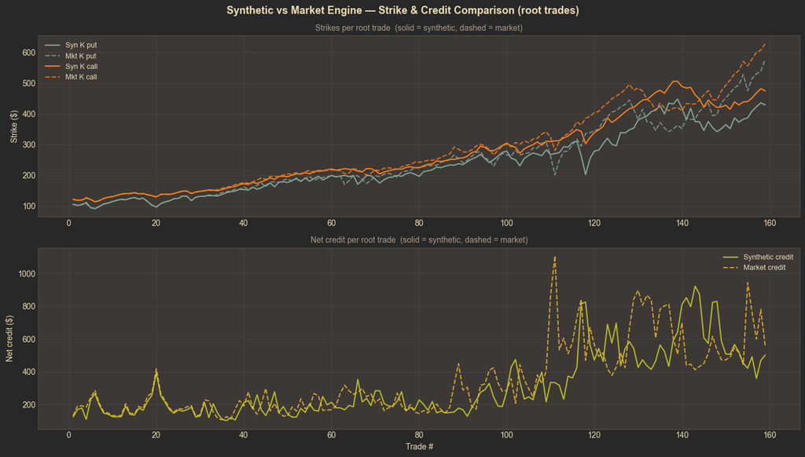

```
Root trades     : syn=174  mkt=159  (syn total rows: 182  mkt total rows: 180)
Total P&L       : synthetic $+6,718.99   market $+2,275.36
Net credit avg  : synthetic $309.72   market $344.92
Entry marks     : 100/159 from DB,  59/159 synthetic fallback

  Mkt credit within  1% of synthetic:   4/159
  Mkt credit within  3% of synthetic:   8/159
  Mkt credit within  5% of synthetic:  15/159
  Mkt credit within 10% of synthetic:  53/159
```

```python
# ── Step 2 validation: MarketEngine vs SyntheticEngine ───────────────────
# Both engines use the same `data` (unadjusted SPY prices), so strikes are
# directly comparable: synthetic BS and DB market data are on the same price scale.
#
# Comparison is done on ROOT trades only (parent_trade_num is None).
# Rolled follow-on trades are engine-mode-dependent and not comparable 1-to-1.

synth_engine = SyntheticEngine(PARAMS)
trades_syn, eq_syn, _ = run_backtest(data, PARAMS, synth_engine)

market_engine = MarketEngine(PARAMS)
trades_mkt, eq_mkt, _ = run_backtest(data, PARAMS, market_engine)
market_engine.close()

# Filter to root trades for the side-by-side comparison
roots_syn = [t for t in trades_syn if t.parent_trade_num is None]
roots_mkt = [t for t in trades_mkt if t.parent_trade_num is None]

# Use the shorter list for 1:1 comparison charts; counts may differ between
# engines because leg rolls and rolls interact differently with each mode.
n = min(len(roots_syn), len(roots_mkt))

# ── Build comparison arrays (root trades only, trimmed to n) ─────────────
# n = min of both lists; all arrays must be the same length for the charts.
trade_nums = list(range(1, n + 1))  # sequential index for x-axis
syn_put_k = [ts.put_strike for ts in roots_syn[:n]]
mkt_put_k = [tm.put_strike for tm in roots_mkt[:n]]
syn_call_k = [ts.call_strike for ts in roots_syn[:n]]
mkt_call_k = [tm.call_strike for tm in roots_mkt[:n]]
syn_credit = [ts.net_credit for ts in roots_syn[:n]]
mkt_credit = [tm.net_credit for tm in roots_mkt[:n]]

# Gruvbox palette (self-contained -- GRV is defined later in the trade log cell)
_C = {
    "bg": "#282828",
    "bg1": "#3c3836",
    "bg2": "#504945",
    "fg": "#ebdbb2",
    "fg2": "#a89984",
    "blue": "#83a598",
    "orange": "#fe8019",
    "green": "#b8bb26",
    "yellow": "#fabd2f",
}

# ── Chart 1: Strikes ─────────────────────────────────────────────────────
fig, (ax1, ax2) = plt.subplots(2, 1, figsize=(14, 8), facecolor=_C["bg"])
fig.suptitle(
    "Synthetic vs Market Engine — Strike & Credit Comparison (root trades)",
    color=_C["fg"],
    fontsize=13,
    fontweight="bold",
)

for ax in (ax1, ax2):
    ax.set_facecolor(_C["bg1"])
    ax.tick_params(colors=_C["fg"])
    ax.spines[:].set_color(_C["bg2"])
    ax.xaxis.label.set_color(_C["fg"])
    ax.yaxis.label.set_color(_C["fg"])
    ax.grid(True, color=_C["bg2"], linewidth=0.5)

ax1.plot(trade_nums, syn_put_k, color=_C["blue"], lw=1.5, label="Syn K put")
ax1.plot(
    trade_nums,
    mkt_put_k,
    color=_C["blue"],
    lw=1.5,
    label="Mkt K put",
    linestyle="--",
    alpha=0.8,
)
ax1.plot(trade_nums, syn_call_k, color=_C["orange"], lw=1.5, label="Syn K call")
ax1.plot(
    trade_nums,
    mkt_call_k,
    color=_C["orange"],
    lw=1.5,
    label="Mkt K call",
    linestyle="--",
    alpha=0.8,
)
ax1.set_ylabel("Strike ($)", color=_C["fg"])
ax1.set_title(
    "Strikes per root trade  (solid = synthetic, dashed = market)",
    color=_C["fg2"],
    fontsize=10,
)
ax1.legend(facecolor=_C["bg2"], labelcolor=_C["fg"], edgecolor=_C["bg2"], fontsize=9)

# ── Chart 2: Credits ─────────────────────────────────────────────────────
ax2.plot(trade_nums, syn_credit, color=_C["green"], lw=1.5, label="Synthetic credit")
ax2.plot(
    trade_nums,
    mkt_credit,
    color=_C["yellow"],
    lw=1.5,
    label="Market credit",
    linestyle="--",
    alpha=0.8,
)
ax2.set_xlabel("Trade #", color=_C["fg"])
ax2.set_ylabel("Net credit ($)", color=_C["fg"])
ax2.set_title(
    "Net credit per root trade  (solid = synthetic, dashed = market)",
    color=_C["fg2"],
    fontsize=10,
)
ax2.legend(facecolor=_C["bg2"], labelcolor=_C["fg"], edgecolor=_C["bg2"], fontsize=9)

plt.tight_layout()
plt.show()

# ── Summary statistics ────────────────────────────────────────────────────
pnl_syn = sum(t.pnl for t in trades_syn)
pnl_mkt = sum(t.pnl for t in trades_mkt)
print(
    f"Root trades     : syn={len(roots_syn)}  mkt={len(roots_mkt)}  "
    f"(syn total rows: {len(trades_syn)}  mkt total rows: {len(trades_mkt)})"
)
print(f"Total P&L       : synthetic ${pnl_syn:+,.2f}   market ${pnl_mkt:+,.2f}")
print(
    f"Net credit avg  : synthetic ${sum(syn_credit)/len(syn_credit):.2f}   "
    f"market ${sum(mkt_credit)/len(mkt_credit):.2f}"
)

# DB vs synthetic fallback breakdown
n_db = sum(1 for tm in roots_mkt if tm.used_market_data)
n_synth = sum(1 for tm in roots_mkt if not tm.used_market_data)
print(f"Entry marks     : {n_db}/{n} from DB,  {n_synth}/{n} synthetic fallback")
print()
for pct in (1, 3, 5, 10):
    count = sum(
        1
        for sc, mc in zip(syn_credit, mkt_credit)
        if abs(mc - sc) / max(sc, 0.01) < pct / 100
    )
    print(f"  Mkt credit within {pct:>2}% of synthetic: {count:>3}/{n}")
```

## 5. Trade Log

| Column | Description |
| --- | --- |
| `Net Credit $` | Dollar credit received after fill adjustment and open commission |
| `Exit Type` | **PROFIT** = 50% hit \| **STOP** = -200% loss \| **21DTE** = time exit \| **EXPIRY** = held to expiry |
| `P&L $` | Realised profit/loss in dollars |
| `P&L %` | P&L as % of net credit received |
| `Balance $` | Running account balance after this trade |

```python
balance = PARAMS["initial_balance"]
rows = []
for t in trades:
    balance += t.pnl
    rows.append(
        {
            "#": t.trade_num,
            "Parent #": (
                int(t.parent_trade_num) if t.parent_trade_num is not None else ""
            ),
            "Entry": t.entry_date.strftime("%Y-%m-%d"),
            "Expiry": t.expiration.strftime("%Y-%m-%d"),
            "DTE": t.entry_dte,
            "Put K": f"{t.put_strike:.1f}",
            "Call K": f"{t.call_strike:.1f}",
            "VIX": f"{t.entry_vix:.1f}",
            "Net Credit $": f"{t.net_credit:.2f}",
            "Exit Date": t.exit_date.strftime("%Y-%m-%d"),
            "Exit DTE": t.exit_dte,
            "Days": (t.exit_date - t.entry_date).days,
            "Exit Type": (
                f"{t.exit_type}/{t.stop_regime}" if t.stop_regime else t.exit_type
            ),
            "Leg Rolls": ("" if not t.leg_rolls else "L" + str(len(t.leg_rolls))),
            "P&L $": f"{t.pnl:+.0f}",
            "P&L %": f"{t.pnl_pct*100:+.1f}%",
            "Balance $": f"{balance:,.0f}",
        }
    )

trade_log = pd.DataFrame(rows).set_index("#")


# Gruvbox palette
# bg shades: bg=#282828, bg1=#3c3836, bg2=#504945, bg3=#665c54
# fg=#ebdbb2, red=#cc241d, green=#98971a, yellow=#d79921, blue=#458588
GRV = {
    "bg": "#282828",
    "bg1": "#3c3836",
    "bg2": "#504945",
    "fg": "#ebdbb2",
    "fg_dim": "#a89984",
    "green": "#98971a",
    "red": "#cc241d",
    "yellow": "#d79921",
    "blue": "#458588",
    "bright_green": "#b8bb26",
    "bright_red": "#fb4934",
    "bright_yellow": "#fabd2f",
    "bright_blue": "#83a598",
}

ROW_STYLES = {
    "PROFIT": f'background-color:{GRV["bg2"]};color:{GRV["bright_green"]};font-weight:600',
    "STOP": f'background-color:{GRV["bg2"]};color:{GRV["bright_red"]};font-weight:600',
    "21DTE": f'background-color:{GRV["bg2"]};color:{GRV["bright_yellow"]};font-weight:600',
    "EXPIRY": f'background-color:{GRV["bg2"]};color:{GRV["bright_blue"]};font-weight:600',
    "ROLLED": f'background-color:{GRV["bg2"]};color:#d3869b;font-weight:600',
}


def colour_exit(row):
    """Colour the entire row by exit type. STOP sub-regimes (STOP/VIOLENT etc.)
    are matched on the leading "STOP" prefix.
    """
    base = f'background-color:{GRV["bg1"]};color:{GRV["fg"]}'
    # Exit Type cell contains "STOP/VIOLENT", "STOP/GAP" etc — match on prefix
    exit_key = row["Exit Type"].split("/")[0]
    row_style = ROW_STYLES.get(exit_key, base)
    return [row_style] * len(row)


caption_style = (
    f"caption-side:top;font-size:13px;font-weight:700;"
    f'color:{GRV["fg"]};background-color:{GRV["bg"]};padding:6px 0'
)

display(
    trade_log.style.apply(colour_exit, axis=1)
    .set_caption(
        f"Trade Log — {len(trades)} trades  |  "
        f"Winners: {sum(t.pnl > 0 for t in trades)}  |  "
        f"Losers: {sum(t.pnl <= 0 for t in trades)}"
    )
    .set_table_styles(
        [
            {"selector": "caption", "props": caption_style},
            {
                "selector": "thead th",
                "props": f'background-color:{GRV["bg"]};color:{GRV["fg_dim"]};border-bottom:1px solid {GRV["bg2"]};font-size:12px',
            },
            {"selector": "tbody td", "props": f"border:none;font-size:12px"},
            {
                "selector": "tbody tr:nth-child(even) td",
                "props": f'background-color:{GRV["bg"]}',
            },
            {
                "selector": "tbody tr:nth-child(odd) td",
                "props": f'background-color:{GRV["bg1"]}',
            },
            {
                "selector": "tbody tr:hover td",
                "props": f'background-color:{GRV["bg2"]}',
            },
        ]
    )
)
```

Trade Log — 180 trades | Winners: 137 | Losers: 43

| # | Parent # | Entry | Expiry | DTE | Put K | Call K | VIX | Net Credit $ | Exit Date | Exit DTE | Days | Exit Type | Leg Rolls | P&L $ | P&L % | Balance $ |
| --- | --- | --- | --- | --- | --- | --- | --- | --- | --- | --- | --- | --- | --- | --- | --- | --- |
| 1 |  | 2010-01-05 | 2010-02-19 | 45 | 106.0 | 122.0 | 19.4 | 131.09 | 2010-01-19 | 31 | 14 | PROFIT |  | +75 | +57.0% | 50,075 |
| 2 |  | 2010-02-02 | 2010-03-19 | 45 | 102.0 | 119.0 | 21.5 | 189.79 | 2010-02-16 | 31 | 14 | PROFIT | L2 | +35 | +18.4% | 50,110 |
| 3 |  | 2010-03-02 | 2010-04-16 | 45 | 105.0 | 120.0 | 19.1 | 191.91 | 2010-03-26 | 21 | 24 | ROLLED | L2 | +62 | +32.2% | 50,171 |
| 4 | 3 | 2010-03-26 | 2010-05-21 | 56 | 108.0 | 125.0 | 17.8 | 133.08 | 2010-04-30 | 21 | 35 | PROFIT |  | +64 | +48.4% | 50,236 |
| 5 |  | 2010-05-04 | 2010-06-18 | 45 | 108.0 | 128.0 | 23.8 | 183.49 | 2010-05-12 | 37 | 8 | PROFIT | L1 | +6 | +3.5% | 50,242 |
| 6 |  | 2010-06-01 | 2010-07-16 | 45 | 95.0 | 122.0 | 35.5 | 242.01 | 2010-06-10 | 36 | 9 | PROFIT |  | +132 | +54.7% | 50,375 |
| 7 |  | 2010-07-06 | 2010-08-20 | 45 | 92.0 | 114.0 | 29.6 | 285.10 | 2010-07-30 | 21 | 24 | ROLLED | L2 | +136 | +47.8% | 50,511 |
| 8 | 7 | 2010-07-30 | 2010-09-17 | 49 | 101.0 | 120.0 | 23.5 | 171.04 | 2010-08-27 | 21 | 28 | PROFIT |  | +94 | +54.7% | 50,604 |
| 9 |  | 2010-09-01 | 2010-10-15 | 44 | 99.0 | 118.0 | 23.9 | 205.97 | 2010-09-24 | 21 | 23 | 21DTE | L1 | +32 | +15.5% | 50,636 |
| 10 |  | 2010-10-05 | 2010-11-19 | 45 | 107.0 | 125.0 | 21.8 | 154.67 | 2010-10-15 | 35 | 10 | PROFIT |  | +78 | +50.5% | 50,714 |
| 11 |  | 2010-11-02 | 2010-12-17 | 45 | 110.0 | 129.0 | 21.6 | 148.11 | 2010-11-11 | 36 | 9 | PROFIT |  | +72 | +48.7% | 50,787 |
| 12 |  | 2010-12-07 | 2011-01-21 | 45 | 115.0 | 131.0 | 18.0 | 132.16 | 2010-12-17 | 35 | 10 | PROFIT |  | +64 | +48.2% | 50,850 |
| 13 |  | 2011-01-04 | 2011-02-18 | 45 | 119.0 | 135.0 | 17.4 | 131.18 | 2011-01-24 | 25 | 20 | PROFIT |  | +65 | +49.9% | 50,916 |
| 14 |  | 2011-02-01 | 2011-03-18 | 45 | 122.0 | 139.0 | 17.6 | 131.90 | 2011-02-25 | 21 | 24 | PROFIT |  | +74 | +55.9% | 50,989 |
| 15 |  | 2011-03-01 | 2011-04-15 | 45 | 121.0 | 141.0 | 21.0 | 205.22 | 2011-03-21 | 25 | 20 | PROFIT | L1 | +106 | +51.7% | 51,095 |
| 16 |  | 2011-04-05 | 2011-05-20 | 45 | 125.0 | 141.0 | 17.2 | 146.93 | 2011-04-15 | 35 | 10 | PROFIT |  | +73 | +49.4% | 51,168 |
| 17 |  | 2011-05-03 | 2011-06-17 | 45 | 128.0 | 144.0 | 16.7 | 142.94 | 2011-05-19 | 29 | 16 | PROFIT |  | +79 | +55.5% | 51,247 |
| 18 |  | 2011-06-01 | 2011-07-15 | 44 | 123.0 | 140.0 | 18.3 | 188.23 | 2011-06-22 | 23 | 21 | PROFIT | L1 | +76 | +40.3% | 51,323 |
| 19 |  | 2011-07-05 | 2011-08-19 | 45 | 126.0 | 141.0 | 16.1 | 176.98 | 2011-07-29 | 21 | 24 | 21DTE | L1 | -91 | -51.2% | 51,233 |
| 20 |  | 2011-08-02 | 2011-09-16 | 45 | 115.0 | 137.0 | 24.8 | 250.50 | 2011-08-26 | 21 | 24 | 21DTE | L2 | -97 | -38.7% | 51,136 |
| 21 |  | 2011-09-06 | 2011-10-21 | 45 | 103.0 | 134.0 | 37.0 | 270.25 | 2011-09-16 | 35 | 10 | PROFIT |  | +150 | +55.4% | 51,286 |
| 22 |  | 2011-10-04 | 2011-11-18 | 45 | 97.0 | 130.0 | 40.8 | 417.44 | 2011-10-28 | 21 | 24 | 21DTE | L2 | +128 | +30.7% | 51,414 |
| 23 |  | 2011-11-01 | 2011-12-16 | 45 | 108.0 | 138.0 | 34.8 | 268.01 | 2011-11-14 | 32 | 13 | PROFIT |  | +144 | +53.8% | 51,558 |
| 24 |  | 2011-12-06 | 2012-01-20 | 45 | 114.0 | 139.0 | 28.1 | 223.79 | 2011-12-20 | 31 | 14 | PROFIT |  | +150 | +66.9% | 51,707 |
| 25 |  | 2012-01-03 | 2012-02-17 | 45 | 117.0 | 138.0 | 23.0 | 177.73 | 2012-01-18 | 30 | 15 | PROFIT |  | +86 | +48.6% | 51,794 |
| 26 |  | 2012-02-01 | 2012-03-16 | 44 | 124.0 | 141.0 | 18.5 | 154.66 | 2012-02-23 | 22 | 22 | PROFIT |  | +81 | +52.6% | 51,875 |
| 27 |  | 2012-03-06 | 2012-04-20 | 45 | 125.0 | 145.0 | 20.9 | 174.47 | 2012-03-12 | 39 | 6 | PROFIT |  | +108 | +61.6% | 51,983 |
| 28 |  | 2012-04-03 | 2012-05-18 | 45 | 133.0 | 149.0 | 15.7 | 171.43 | 2012-04-20 | 28 | 17 | PROFIT | L1 | +16 | +9.3% | 51,999 |
| 29 |  | 2012-05-01 | 2012-06-15 | 45 | 132.0 | 149.0 | 16.6 | 185.46 | 2012-05-25 | 21 | 24 | 21DTE | L2 | -127 | -68.3% | 51,872 |
| 30 |  | 2012-06-05 | 2012-07-20 | 45 | 118.0 | 141.0 | 24.7 | 192.45 | 2012-06-18 | 32 | 13 | PROFIT |  | +116 | +60.2% | 51,988 |

[output cut: 150 more lines]

```python
# ── Leg Roll Events table ────────────────────────────────────────────────
# Lists every individual defensive leg roll event chronologically.
# Only shown when at least one event occurred.
_lr_rows = []
for t in trades:
    for ev in t.leg_rolls:
        _lr_rows.append(
            {
                "Trade #": t.trade_num,
                "Entry": t.entry_date.strftime("%Y-%m-%d"),
                "Event Date": ev.event_date.strftime("%Y-%m-%d"),
                "Side Rolled": ev.side,
                "Old Strike": f"{ev.old_strike:.1f}",
                "New Strike": f"{ev.new_strike:.1f}",
                "Trigger |Δ|": f"{ev.trigger_delta:.3f}",
                "Close Cost/sh": f"${ev.close_cost_ps:.4f}",
                "New Credit/sh": f"${ev.new_credit_ps:.4f}",
                "Net Credit $": f"${ev.net_credit_dollar:.2f}",
            }
        )

if _lr_rows:
    _lr_df = pd.DataFrame(_lr_rows)
    display(
        _lr_df.style.hide(axis="index")
        .set_caption(
            f"Leg Roll Events — {len(_lr_rows)} events across "
            f"{sum(1 for t in trades if t.leg_rolls)} trades"
        )
        .set_table_styles([{"selector": "caption", "props": caption_style}])
    )
else:
    print("No leg roll events in this backtest run.")
```

Leg Roll Events — 179 events across 96 trades

| Trade # | Entry | Event Date | Side Rolled | Old Strike | New Strike | Trigger \|Δ\| | Close Cost/sh | New Credit/sh | Net Credit $ |
| --- | --- | --- | --- | --- | --- | --- | --- | --- | --- |
| 2 | 2010-02-02 | 2010-02-04 | call | 119.0 | 116.0 | 0.315 | $0.4534 | $0.8100 | $33.65 |
| 2 | 2010-02-02 | 2010-02-08 | call | 116.0 | 115.0 | 0.330 | $0.6512 | $0.7917 | $12.05 |
| 3 | 2010-03-02 | 2010-03-17 | put | 105.0 | 111.0 | 0.310 | $0.0447 | $0.5038 | $43.91 |
| 3 | 2010-03-02 | 2010-03-23 | put | 111.0 | 112.0 | 0.303 | $0.2857 | $0.4224 | $11.68 |
| 5 | 2010-05-04 | 2010-05-06 | call | 128.0 | 127.0 | 0.336 | $0.8114 | $0.9327 | $10.14 |
| 7 | 2010-07-06 | 2010-07-13 | put | 92.0 | 101.0 | 0.320 | $0.0720 | $0.8508 | $75.88 |
| 7 | 2010-07-06 | 2010-07-23 | put | 101.0 | 103.0 | 0.317 | $0.3864 | $0.6716 | $26.52 |
| 9 | 2010-09-01 | 2010-09-24 | put | 99.0 | 109.0 | 0.303 | $0.0094 | $0.6353 | $60.59 |
| 15 | 2011-03-01 | 2011-03-16 | call | 141.0 | 137.0 | 0.309 | $0.4315 | $0.8753 | $42.38 |
| 18 | 2011-06-01 | 2011-06-15 | call | 140.0 | 135.0 | 0.304 | $0.1635 | $0.6065 | $42.30 |
| 19 | 2011-07-05 | 2011-07-29 | call | 141.0 | 137.0 | 0.335 | $0.2446 | $0.6688 | $40.43 |
| 20 | 2011-08-02 | 2011-08-04 | call | 137.0 | 134.0 | 0.332 | $0.6933 | $1.0463 | $33.31 |
| 20 | 2011-08-02 | 2011-08-08 | call | 134.0 | 132.0 | 0.521 | $1.1115 | $1.3441 | $21.26 |
| 22 | 2011-10-04 | 2011-10-24 | put | 97.0 | 116.0 | 0.330 | $0.0030 | $0.9636 | $94.07 |
| 22 | 2011-10-04 | 2011-10-27 | put | 116.0 | 120.0 | 0.442 | $0.2462 | $0.7015 | $43.53 |
| 28 | 2012-04-03 | 2012-04-10 | call | 149.0 | 145.0 | 0.369 | $0.2989 | $0.7173 | $39.84 |
| 29 | 2012-05-01 | 2012-05-09 | call | 149.0 | 145.0 | 0.332 | $0.2528 | $0.6340 | $36.12 |
| 29 | 2012-05-01 | 2012-05-10 | call | 145.0 | 144.0 | 0.311 | $0.5315 | $0.6704 | $11.90 |
| 33 | 2012-09-04 | 2012-09-13 | put | 132.0 | 140.0 | 0.303 | $0.0372 | $0.6402 | $58.29 |
| 33 | 2012-09-04 | 2012-09-26 | call | 150.0 | 149.0 | 0.300 | $0.3931 | $0.5381 | $12.49 |
| 35 | 2012-11-06 | 2012-11-08 | call | 152.0 | 147.0 | 0.322 | $0.2215 | $0.6944 | $45.30 |
| 35 | 2012-11-06 | 2012-11-13 | call | 147.0 | 145.0 | 0.308 | $0.3774 | $0.6333 | $23.59 |
| 41 | 2013-05-07 | 2013-05-17 | put | 155.0 | 160.0 | 0.320 | $0.1112 | $0.5783 | $44.71 |
| 42 | 2013-06-04 | 2013-06-24 | call | 173.0 | 165.0 | 0.356 | $0.0924 | $0.7223 | $60.98 |
| 43 | 2013-06-28 | 2013-07-11 | put | 150.0 | 160.0 | 0.318 | $0.0308 | $0.7429 | $69.21 |
| 43 | 2013-06-28 | 2013-07-15 | put | 160.0 | 161.0 | 0.342 | $0.5018 | $0.6576 | $13.58 |
| 44 | 2013-08-06 | 2013-08-16 | call | 177.0 | 173.0 | 0.308 | $0.2082 | $0.6254 | $39.72 |
| 44 | 2013-08-06 | 2013-08-19 | call | 173.0 | 172.0 | 0.356 | $0.4735 | $0.6132 | $11.97 |
| 45 | 2013-09-03 | 2013-09-16 | put | 155.0 | 163.0 | 0.308 | $0.0634 | $0.7359 | $65.25 |
| 45 | 2013-09-03 | 2013-09-18 | put | 163.0 | 166.0 | 0.450 | $0.2681 | $0.6431 | $35.49 |

[output cut: 149 more lines]

## 6. Performance Metrics

- **Annual return**: geometric annualisation over the full period
- **Sharpe**: annualised excess return / std dev of daily mark-to-market P&L (true MTM; prior spread-based values are not comparable)
- **Max drawdown**: largest peak-to-trough decline in equity (on trade close dates)
- **Calmar**: annual return / |max drawdown|

```python
def compute_metrics(trades, equity_curve, params, data):
    """
    Sharpe is computed from true daily mark-to-market changes recorded in
    Trade.daily_marks, NOT from realized P&L spread evenly across holding days.
    The MTM approach correctly captures single-day jump risk (e.g. vol spikes
    on 2018-02-05, 2020-03-12). Prior versions using the spread method produced
    materially higher Sharpe values that are NOT comparable to the current metric.
    """
    if not trades:
        return {}
    pnls = np.array([t.pnl for t in trades])
    pcts = np.array([t.pnl_pct for t in trades])
    n = len(trades)

    def _stats(xt):
        ts = [t for t in trades if t.exit_type == xt]
        if not ts:
            return 0, float("nan"), float("nan")
        a = np.array([t.pnl for t in ts])
        return len(ts), float((a > 0).mean()), float(a.mean())

    streak = max_streak = 0
    for p in pnls:
        streak = streak + 1 if p < 0 else 0
        max_streak = max(max_streak, streak)

    init = params["initial_balance"]
    final = init + float(pnls.sum())
    years = (
        pd.Timestamp(params["end_date"]) - pd.Timestamp(params["start_date"])
    ).days / 365.25
    ann = (final / init) ** (1.0 / years) - 1.0 if years > 0 else 0.0

    # Build a true mark-to-market daily P&L series.
    # Days with no open position contribute 0 — omitting them would
    # overstate Sharpe by excluding flat/idle periods.
    # Each day's P&L = change in position mark vs the prior day.
    all_days = data.loc[
        pd.Timestamp(params["start_date"]) : pd.Timestamp(params["end_date"])
    ].index
    daily_pnl = pd.Series(0.0, index=all_days)
    for t in trades:
        marks = t.daily_marks
        if not marks or len(marks) < 2:
            # Fallback for any trade missing MTM data
            if t.exit_date in daily_pnl.index:
                daily_pnl[t.exit_date] += t.pnl
            continue
        for i in range(1, len(marks)):
            prev_date, prev_val = marks[i - 1]
            this_date, this_val = marks[i]
            day_change = this_val - prev_val
            if this_date in daily_pnl.index:
                daily_pnl[this_date] += day_change
    d = daily_pnl.values
    rf = params["risk_free_rate"] / 252
    sharpe = (
        float((d.mean() - rf) / d.std(ddof=1) * np.sqrt(252))
        if len(d) > 1
        else float("nan")
    )

    eq = equity_curve.values
    pk = np.maximum.accumulate(eq)
    mdd = float(((eq - pk) / pk).min()) if len(eq) else 0.0

    n_p, wr_p, avg_p = _stats("PROFIT")
    n_s, wr_s, avg_s = _stats("STOP")
    n_d, wr_d, avg_d = _stats("21DTE")
    n_e, wr_e, avg_e = _stats("EXPIRY")
    n_r, wr_r, avg_r = _stats("ROLLED")

    # ── Chain-collapsed win/loss (root trades only) ───────────────────────
    # ROLLED rows are mid-chain accountancy entries, not independent outcomes.
    # A logical position = root trade + all descendants. Win = chain P&L > 0.
    by_num = {t.trade_num: t for t in trades}
    chain_pnls = []
    for t in trades:
        if t.parent_trade_num is not None:
            continue  # skip rolled descendants -- counted via their root
        chain_pnl = t.pnl
        cur = t
        while cur.child_trade_num is not None:
            cur = by_num[cur.child_trade_num]
            chain_pnl += cur.pnl
        chain_pnls.append(chain_pnl)
    chain_pnls = np.array(chain_pnls)
    n_chains = len(chain_pnls)
    wr_chain = float((chain_pnls > 0).mean()) if n_chains else float("nan")
    avg_chain = float(chain_pnls.mean()) if n_chains else float("nan")

    streak_chain = max_streak_chain = 0
    for cp in chain_pnls:
        streak_chain = streak_chain + 1 if cp < 0 else 0
        max_streak_chain = max(max_streak_chain, streak_chain)

    # Stop regime breakdown
    def _regime_stats(regime):
        ts = [t for t in trades if t.exit_type == "STOP" and t.stop_regime == regime]
        if not ts:
            return 0, float("nan")
        a = np.array([t.pnl for t in ts])
        return len(ts), float(a.mean())

    n_stop_orderly, avg_stop_orderly = _regime_stats("ORDERLY")
    n_stop_normal, avg_stop_normal = _regime_stats("NORMAL")
    n_stop_violent, avg_stop_violent = _regime_stats("VIOLENT")
    n_stop_gap, avg_stop_gap = _regime_stats("GAP")

    # ── Defensive leg roll stats ─────────────────────────────────────────
    n_lr_trades = sum(1 for t in trades if t.leg_rolls)
    all_lr_events = [ev for t in trades for ev in t.leg_rolls]
    n_lr_events = len(all_lr_events)
    avg_lr_per_trade = float(n_lr_events / len(trades)) if trades else 0.0
    avg_lr_per_rolled = (
        float(n_lr_events / n_lr_trades) if n_lr_trades else float("nan")
    )
    lr_total_credit = float(sum(ev.net_credit_dollar for ev in all_lr_events))

    return dict(
        n=n,
        init=init,
        final=final,
        tot=(final - init) / init,
        ann=ann,
        sharpe=sharpe,
        mdd=mdd,
        calmar=ann / abs(mdd) if mdd else float("nan"),
        wr=float((pnls > 0).mean()),
        avg_pnl=float(pnls.mean()),
        avg_pct=float(pcts.mean()),
        max_streak=max_streak,
        n_p=n_p,
        wr_p=wr_p,
        avg_p=avg_p,
        n_s=n_s,
        wr_s=wr_s,
        avg_s=avg_s,
        n_d=n_d,
        wr_d=wr_d,
        avg_d=avg_d,
        n_e=n_e,
        wr_e=wr_e,
        avg_e=avg_e,
        n_r=n_r,
        wr_r=wr_r,
        avg_r=avg_r,
        n_stop_orderly=n_stop_orderly,
        avg_stop_orderly=avg_stop_orderly,
        n_stop_normal=n_stop_normal,
        avg_stop_normal=avg_stop_normal,
        n_stop_violent=n_stop_violent,
        avg_stop_violent=avg_stop_violent,
        n_stop_gap=n_stop_gap,
        avg_stop_gap=avg_stop_gap,
        # chain-collapsed
        n_chains=n_chains,
        wr_chain=wr_chain,
        avg_chain=avg_chain,
        max_streak_chain=max_streak_chain,
        # leg roll
        n_lr_trades=n_lr_trades,
        n_lr_events=n_lr_events,
        avg_lr_per_trade=avg_lr_per_trade,
        avg_lr_per_rolled=avg_lr_per_rolled,
        lr_total_credit=lr_total_credit,
    )


m = compute_metrics(trades, equity_curve, PARAMS, data)

p = lambda v: f"{v*100:.1f}%" if v == v else "N/A"
d = lambda v: f"${v:,.2f}" if v == v else "N/A"
f2 = lambda v: f"{v:.2f}" if v == v else "N/A"
sa = lambda v: d(v) if v == v else "—"

rows = [
    ("── Overview", "", ""),
    ("Total trade rows", str(m["n"]), "incl. rolled descendants"),
    ("Initial balance", d(m["init"]), ""),
    ("Final balance", d(m["final"]), ""),
    ("Total return", p(m["tot"]), ""),
    ("Annual return", p(m["ann"]), "geometric"),
    ("Sharpe ratio", f2(m["sharpe"]), "annualised, excess of Rf"),
    ("Max drawdown", p(m["mdd"]), "peak-to-trough"),
    ("Calmar ratio", f2(m["calmar"]), "annual return / |MDD|"),
    ("── Win / Loss", "", ""),
    (
        "Positions (chains)",
        str(m["n_chains"]),
        "root trades; each chain = 1 logical position",
    ),
    (
        "Win rate (chain)",
        p(m["wr_chain"]),
        "chain P&L > 0; ROLLED rows excluded from count",
    ),
    (
        "Win rate (raw rows)",
        p(m["wr"]),
        "all trade rows incl. ROLLED — inflated by roll accounting",
    ),
    ("Max consecutive losses (chain)", str(m["max_streak_chain"]), ""),
    ("Max consecutive losses (raw)", str(m["max_streak"]), ""),
    ("Avg P&L / chain", d(m["avg_chain"]), ""),
    ("Avg P&L / trade row", d(m["avg_pnl"]), p(m["avg_pct"]) + " of premium"),
    ("── Exit breakdown", "", ""),
    ("PROFIT (50%)", f"{m['n_p']} | WR {p(m['wr_p'])} | avg {sa(m['avg_p'])}", ""),
    ("STOP (200%)", f"{m['n_s']} | WR {p(m['wr_s'])} | avg {sa(m['avg_s'])}", ""),
    (
        "  ORDERLY",
        f"{m['n_stop_orderly']} | avg {sa(m['avg_stop_orderly'])}",
        f"range < {PARAMS['range_threshold_orderly']*100:.1f}%, overshoot={PARAMS['overshoot_orderly']:.0%}",
    ),
    (
        "  NORMAL",
        f"{m['n_stop_normal']} | avg {sa(m['avg_stop_normal'])}",
        f"range < {PARAMS['range_threshold_violent']*100:.1f}%, overshoot={PARAMS['overshoot_normal']:.0%}",
    ),
    (
        "  VIOLENT",
        f"{m['n_stop_violent']} | avg {sa(m['avg_stop_violent'])}",
        f"range >= {PARAMS['range_threshold_violent']*100:.1f}%, overshoot={PARAMS['overshoot_violent']:.0%}",
    ),
    (
        "  GAP",
        f"{m['n_stop_gap']} | avg {sa(m['avg_stop_gap'])}",
        "overnight gap, overshoot=100%",
    ),
    ("21DTE", f"{m['n_d']} | WR {p(m['wr_d'])} | avg {sa(m['avg_d'])}", ""),
    ("EXPIRY", f"{m['n_e']} | avg {sa(m['avg_e'])}", ""),
    (
        "ROLLED",
        f"{m['n_r']} | avg {sa(m['avg_r'])}",
        "closed at 21 DTE as part of a successful roll (always a loss at roll time)",
    ),
    ("── Defensive Leg Rolls", "", ""),
    ("Trades with leg roll", str(m["n_lr_trades"]), f"of {m['n']} total rows"),
    ("Total leg roll events", str(m["n_lr_events"]), ""),
    ("Avg events / trade", f"{m['avg_lr_per_trade']:.3f}", "across all trades"),
    (
        "Avg events / rolled trade",
        f2(m["avg_lr_per_rolled"]),
        "among trades that rolled",
    ),
    ("Leg roll total credit", d(m["lr_total_credit"]), "net credit from all leg rolls"),
    ("── SPY Benchmark", "", "buy-and-hold, same period"),
    ("SPY total return", p(spy_total_return), ""),
    ("SPY Sharpe ratio", f2(spy_sharpe), "annualised, excess of Rf"),
]

pd.DataFrame(rows, columns=["Metric", "Value", "Notes"]).style.hide(
    axis="index"
).set_caption("Performance Summary")
```

Performance Summary

| Metric | Value | Notes |
| --- | --- | --- |
| ── Overview |  |  |
| Total trade rows | 180 | incl. rolled descendants |
| Initial balance | $50,000.00 |  |
| Final balance | $52,275.36 |  |
| Total return | 4.6% |  |
| Annual return | 0.3% | geometric |
| Sharpe ratio | 0.09 | annualised, excess of Rf |
| Max drawdown | -10.4% | peak-to-trough |
| Calmar ratio | 0.03 | annual return / \|MDD\| |
| ── Win / Loss |  |  |
| Positions (chains) | 159 | root trades; each chain = 1 logical position |
| Win rate (chain) | 74.2% | chain P&L > 0; ROLLED rows excluded from count |
| Win rate (raw rows) | 76.1% | all trade rows incl. ROLLED — inflated by roll accounting |
| Max consecutive losses (chain) | 4 |  |
| Max consecutive losses (raw) | 4 |  |
| Avg P&L / chain | $14.31 |  |
| Avg P&L / trade row | $12.64 | 13.3% of premium |
| ── Exit breakdown |  |  |
| PROFIT (50%) | 100 \| WR 100.0% \| avg $133.18 |  |
| STOP (200%) | 0 \| WR N/A \| avg — |  |
| ORDERLY | 0 \| avg — | range < 1.5%, overshoot=25% |
| NORMAL | 0 \| avg — | range < 3.0%, overshoot=50% |
| VIOLENT | 0 \| avg — | range >= 3.0%, overshoot=80% |
| GAP | 0 \| avg — | overnight gap, overshoot=100% |
| 21DTE | 59 \| WR 28.8% \| avg $-221.00 |  |
| EXPIRY | 0 \| avg — |  |
| ROLLED | 21 \| avg $95.08 | closed at 21 DTE as part of a successful roll (always a loss at roll time) |
| ── Defensive Leg Rolls |  |  |
| Trades with leg roll | 96 | of 180 total rows |
| Total leg roll events | 179 |  |
| Avg events / trade | 0.994 | across all trades |
| Avg events / rolled trade | 1.86 | among trades that rolled |
| Leg roll total credit | $10,579.21 | net credit from all leg rolls |
| ── SPY Benchmark |  | buy-and-hold, same period |
| SPY total return | 419.0% |  |
| SPY Sharpe ratio | 0.66 | annualised, excess of Rf |

```python
# VIX Regime Breakdown
# Classification uses max_vix (peak VIX during the hold period), not entry_vix.
# A trade entered at VIX=14 that spikes to VIX=35 intraperiod is correctly
# attributed to the High regime, not Low. Entry VIX is shown separately.
lo, hi = PARAMS["vix_low"], PARAMS["vix_high"]
buckets = {
    f"Low  (maxVIX<{lo})": [t for t in trades if t.max_vix < lo],
    f"Normal (maxVIX {lo}–{hi})": [t for t in trades if lo <= t.max_vix < hi],
    f"High (maxVIX≥{hi})": [t for t in trades if t.max_vix >= hi],
}
regime_rows = []
for regime, ts in buckets.items():
    if not ts:
        regime_rows.append(
            {
                "Regime": regime,
                "# Trades": 0,
                "Win Rate": "—",
                "Avg Entry VIX": "—",
                "Avg Max VIX": "—",
                "Avg P&L $": "—",
                "Avg P&L %": "—",
                "Total P&L $": "—",
            }
        )
    else:
        a = np.array([t.pnl for t in ts])
        b = np.array([t.pnl_pct for t in ts])
        regime_rows.append(
            {
                "Regime": regime,
                "# Trades": len(ts),
                "Win Rate": f"{(a>0).mean()*100:.0f}%",
                "Avg Entry VIX": f"{np.mean([t.entry_vix for t in ts]):.1f}",
                "Avg Max VIX": f"{np.mean([t.max_vix for t in ts]):.1f}",
                "Avg P&L $": f"${a.mean():,.2f}",
                "Avg P&L %": f"{b.mean()*100:.1f}%",
                "Total P&L $": f"${a.sum():,.2f}",
            }
        )

pd.DataFrame(regime_rows).style.hide(axis="index").set_caption(
    "Performance by VIX Regime"
)
```

Performance by VIX Regime

| Regime | # Trades | Win Rate | Avg Entry VIX | Avg Max VIX | Avg P&L $ | Avg P&L % | Total P&L $ |
| --- | --- | --- | --- | --- | --- | --- | --- |
| Low (maxVIX<15) | 30 | 87% | 12.4 | 13.4 | $15.71 | 12.5% | $471.39 |
| Normal (maxVIX 15–25) | 96 | 83% | 16.8 | 19.1 | $65.77 | 28.9% | $6,314.02 |
| High (maxVIX≥25) | 54 | 57% | 25.0 | 33.2 | $-83.52 | -14.0% | $-4,510.05 |

## 7. Visualizations

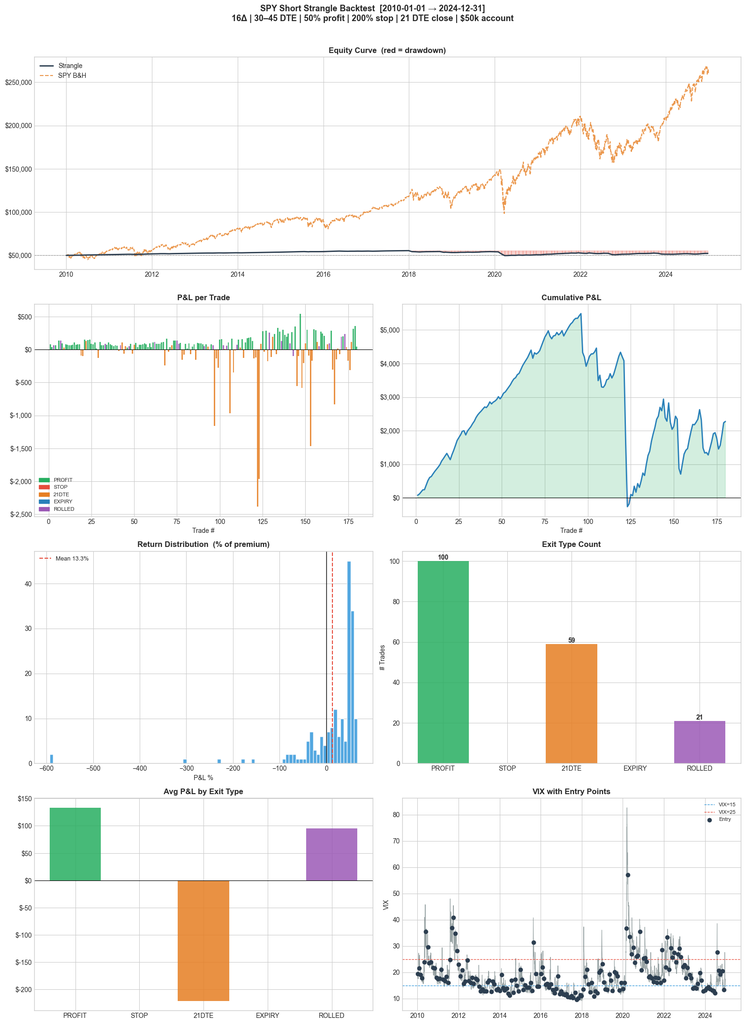

```
Saved: backtest_results.png
```

```python
def plot_backtest(trades, equity_curve, data, params):
    EC = {
        "PROFIT": "#27ae60",
        "STOP": "#e74c3c",
        "21DTE": "#e67e22",
        "EXPIRY": "#2980b9",
        "ROLLED": "#9b59b6",
    }
    fig = plt.figure(figsize=(16, 22))
    fig.suptitle(
        f'SPY Short Strangle Backtest  [{params["start_date"]} → {params["end_date"]}]\n'
        f"16Δ | 30–45 DTE | 50% profit | 200% stop | 21 DTE close | $50k account",
        fontsize=13,
        fontweight="bold",
        y=0.99,
    )

    eq_dates = [pd.Timestamp(params["start_date"])] + list(equity_curve.index)
    eq_vals = [params["initial_balance"]] + list(equity_curve.values)
    eq_arr = np.array(eq_vals)
    pk_arr = np.maximum.accumulate(eq_arr)

    # 1. Equity curve
    ax1 = fig.add_subplot(4, 2, (1, 2))
    ax1.plot(eq_dates, eq_vals, color="#2c3e50", lw=2, label="Strangle", zorder=3)
    # SPY buy-and-hold normalised to same starting balance
    spy_eq = data.loc[
        pd.Timestamp(params["start_date"]) : pd.Timestamp(params["end_date"]),
        "spy_close",
    ]
    spy_eq = spy_eq / float(spy_eq.iloc[0]) * params["initial_balance"]
    ax1.plot(
        spy_eq.index,
        spy_eq.values,
        color="#e67e22",
        lw=1.5,
        ls="--",
        alpha=0.8,
        label="SPY B&H",
        zorder=2,
    )
    ax1.axhline(params["initial_balance"], color="grey", ls="--", lw=0.8, alpha=0.7)
    for i in range(len(eq_dates) - 1):
        if eq_arr[i] < pk_arr[i]:
            ax1.fill_between(
                [eq_dates[i], eq_dates[i + 1]],
                [pk_arr[i], pk_arr[i + 1]],
                [eq_arr[i], eq_arr[i + 1]],
                alpha=0.25,
                color="#e74c3c",
                zorder=2,
            )
    ax1.yaxis.set_major_formatter(mticker.FuncFormatter(lambda x, _: f"${x:,.0f}"))
    ax1.set_title("Equity Curve  (red = drawdown)", fontweight="bold")
    ax1.legend()

    # 2. P&L per trade
    ax2 = fig.add_subplot(4, 2, 3)
    ax2.bar(
        range(1, len(trades) + 1),
        [t.pnl for t in trades],
        color=[EC.get(t.exit_type, "#95a5a6") for t in trades],
        edgecolor="none",
        alpha=0.85,
    )
    ax2.axhline(0, color="black", lw=0.8)
    ax2.yaxis.set_major_formatter(mticker.FuncFormatter(lambda x, _: f"${x:,.0f}"))
    ax2.set_title("P&L per Trade", fontweight="bold")
    ax2.set_xlabel("Trade #")
    ax2.legend(
        handles=[mpatches.Patch(color=c, label=l) for l, c in EC.items()], fontsize=8
    )

    # 3. Cumulative P&L
    ax3 = fig.add_subplot(4, 2, 4)
    cum = np.cumsum([t.pnl for t in trades])
    x = range(1, len(trades) + 1)
    ax3.plot(x, cum, color="#2980b9", lw=2)
    ax3.fill_between(x, cum, 0, where=cum >= 0, alpha=0.2, color="#27ae60")
    ax3.fill_between(x, cum, 0, where=cum < 0, alpha=0.2, color="#e74c3c")
    ax3.axhline(0, color="black", lw=0.8)
    ax3.yaxis.set_major_formatter(mticker.FuncFormatter(lambda x_, _: f"${x_:,.0f}"))
    ax3.set_title("Cumulative P&L", fontweight="bold")
    ax3.set_xlabel("Trade #")

    # 4. Return distribution
    ax4 = fig.add_subplot(4, 2, 5)
    pct_vals = [t.pnl_pct * 100 for t in trades]
    ax4.hist(
        pct_vals,
        bins=max(8, len(trades) // 2),
        color="#3498db",
        edgecolor="white",
        alpha=0.85,
    )
    ax4.axvline(0, color="black", lw=1)
    ax4.axvline(
        np.mean(pct_vals),
        color="#e74c3c",
        lw=1.5,
        ls="--",
        label=f"Mean {np.mean(pct_vals):.1f}%",
    )
    ax4.set_title("Return Distribution  (% of premium)", fontweight="bold")
    ax4.set_xlabel("P&L %")
    ax4.legend(fontsize=9)

    # 5. Exit type count
    ax5 = fig.add_subplot(4, 2, 6)
    cnts = {k: sum(1 for t in trades if t.exit_type == k) for k in EC}
    bars = ax5.bar(
        cnts.keys(),
        cnts.values(),
        color=list(EC.values()),
        edgecolor="none",
        alpha=0.85,
    )
    ax5.set_title("Exit Type Count", fontweight="bold")
    ax5.set_ylabel("# Trades")
    for bar, v in zip(bars, cnts.values()):
        if v:
            ax5.text(
                bar.get_x() + bar.get_width() / 2,
                bar.get_height() + 0.05,
                str(v),
                ha="center",
                va="bottom",
                fontweight="bold",
            )

    # 6. Avg P&L by exit type
    ax6 = fig.add_subplot(4, 2, 7)
    avgs = {
        k: (
            np.mean([t.pnl for t in trades if t.exit_type == k])
            if any(t.exit_type == k for t in trades)
            else 0
        )
        for k in EC
    }
    ax6.bar(
        avgs.keys(),
        avgs.values(),
        color=list(EC.values()),
        edgecolor="none",
        alpha=0.85,
    )
    ax6.axhline(0, color="black", lw=0.8)
    ax6.yaxis.set_major_formatter(mticker.FuncFormatter(lambda x, _: f"${x:,.0f}"))
    ax6.set_title("Avg P&L by Exit Type", fontweight="bold")

    # 7. VIX with entries
    ax7 = fig.add_subplot(4, 2, 8)
    vx = data.loc[
        pd.Timestamp(params["start_date"]) : pd.Timestamp(params["end_date"]),
        "vix_close",
    ]
    ax7.plot(vx.index, vx.values, color="#7f8c8d", lw=0.8, alpha=0.8)
    ax7.axhline(
        params["vix_low"],
        color="#3498db",
        ls="--",
        lw=0.9,
        label=f'VIX={params["vix_low"]}',
    )
    ax7.axhline(
        params["vix_high"],
        color="#e74c3c",
        ls="--",
        lw=0.9,
        label=f'VIX={params["vix_high"]}',
    )
    ax7.scatter(
        [t.entry_date for t in trades],
        [t.entry_vix for t in trades],
        color="#2c3e50",
        s=35,
        zorder=5,
        label="Entry",
    )
    ax7.set_title("VIX with Entry Points", fontweight="bold")
    ax7.legend(fontsize=8)
    ax7.set_ylabel("VIX")

    plt.tight_layout(rect=[0, 0, 1, 0.98])
    plt.savefig("backtest_results.png", dpi=150, bbox_inches="tight")
    plt.show()
    print("Saved: backtest_results.png")


plot_backtest(trades, equity_curve, data, PARAMS)
```

## 8b. Stop-Loss Overshoot Sensitivity Analysis

Re-runs the backtest with a flat (regime-independent) overshoot fraction from 0% to 100%, showing how total return, Sharpe, max drawdown, and stop count change as the assumed slippage severity increases.

```python
# ── Stop-loss overshoot sensitivity ──────────────────────────────────────
flat_overshoots = [0.0, 0.25, 0.50, 0.75, 1.0]
sens_rows = []
for ov in flat_overshoots:
    p_sens = {
        **PARAMS,
        "overshoot_orderly": ov,
        "overshoot_normal": ov,
        "overshoot_violent": ov,
    }
    t_sens, eq_sens, _ = run_backtest(data, p_sens, make_engine(p_sens))
    m_sens = compute_metrics(t_sens, eq_sens, p_sens, data)
    n_stops = sum(1 for t in t_sens if t.exit_type == "STOP")
    sens_rows.append(
        {
            "Overshoot": f"{ov:.0%}",
            "Total Return": f"{m_sens['tot']*100:+.1f}%",
            "Sharpe": f"{m_sens['sharpe']:.2f}",
            "Max DD": f"{m_sens['mdd']*100:.1f}%",
            "# Stops": n_stops,
            "Avg Stop P&L": (
                f"${np.mean([t.pnl for t in t_sens if t.exit_type=='STOP']):,.0f}"
                if n_stops
                else "—"
            ),
        }
    )

pd.DataFrame(sens_rows).style.hide(axis="index").set_caption(
    "Stop-Loss Overshoot Sensitivity (flat overshoot applied to all regimes)"
)
```

```
MarketEngine: connected to data/Spy Options Database.db
MarketEngine: connected to data/Spy Options Database.db
MarketEngine: connected to data/Spy Options Database.db
MarketEngine: connected to data/Spy Options Database.db
MarketEngine: connected to data/Spy Options Database.db
```

Stop-Loss Overshoot Sensitivity (flat overshoot applied to all regimes)

| Overshoot | Total Return | Sharpe | Max DD | # Stops | Avg Stop P&L |
| --- | --- | --- | --- | --- | --- |
| 0% | +4.6% | 0.09 | -10.4% | 0 | — |
| 25% | +4.6% | 0.09 | -10.4% | 0 | — |
| 50% | +4.6% | 0.09 | -10.4% | 0 | — |
| 75% | +4.6% | 0.09 | -10.4% | 0 | — |
| 100% | +4.6% | 0.09 | -10.4% | 0 | — |

## 8. IBKR Validation (Optional)

Cross-check our Black-Scholes 16Δ strikes against live SPY chains from Interactive Brokers.

**Before enabling:**

1. `pip install ib_insync`
2. Open **TWS** (port 7496 live / 7497 paper) or **IB Gateway** (4001/4002)
3. TWS → `Edit → Global Configuration → API → Settings` → enable *Allow connections from localhost*
4. Set `IBKR_ENABLED = True` below

```python
IBKR_ENABLED = False  # ← set True when TWS / IB Gateway is running
IBKR_PORT = 7497  # 7497 = paper  |  7496 = live

if not IBKR_ENABLED:
    print("IBKR validation disabled. Set IBKR_ENABLED = True and re-run.")
else:
    try:
        from ib_insync import IB, Stock, Option, util
        from IPython.display import display

        util.startLoop()

        ib = IB()
        ib.connect("127.0.0.1", IBKR_PORT, clientId=99)
        print(f"Connected: {ib.isConnected()}")

        spy_c = Stock("SPY", "SMART", "USD")
        ib.qualifyContracts(spy_c)
        spy_tk = ib.reqMktData(spy_c, "", False, False)
        ib.sleep(2)
        S_live = spy_tk.last or spy_tk.close

        vix_live = float(data["vix_close"].iloc[-1])  # fallback to latest
        try:
            vix_c = Stock("VIX", "CBOE", "USD")
            ib.qualifyContracts(vix_c)
            vix_tk = ib.reqMktData(vix_c, "", False, False)
            ib.sleep(2)
            vix_live = vix_tk.last or vix_tk.close
        except Exception:
            pass

        print(f"SPY=${S_live:.2f}  VIX={vix_live:.1f}")

        T_l, sig_l, r_l = 35 / 365, vix_live / 100, PARAMS["risk_free_rate"]
        put_k_s = strike_from_delta(S_live, T_l, r_l, sig_l, 0.16, "put")
        call_k_s = strike_from_delta(S_live, T_l, r_l, sig_l, 0.16, "call")
        today = pd.Timestamp.today().normalize()
        exp = get_monthly_expiration(today, PARAMS["dte_min"], PARAMS["dte_max"])
        exp_str = exp.strftime("%Y%m%d")
        print(
            f"Synth strikes: put=${put_k_s:.0f} / call=${call_k_s:.0f}  |  expiry {exp.date()}"
        )

        def _get(strike, right):
            o = Option("SPY", exp_str, strike, right, "SMART")
            ib.qualifyContracts(o)
            tk = ib.reqMktData(o, "100", False, False)
            ib.sleep(2)
            return tk

        tk_p = _get(put_k_s, "P")
        tk_c = _get(call_k_s, "C")

        def _mid(tk):
            b, a = tk.bid, tk.ask
            return (b + a) / 2 if b and a and b > 0 and a > 0 else float("nan")

        def _dlt(tk):
            try:
                return tk.modelGreeks.delta
            except:
                return float("nan")

        comp = pd.DataFrame(
            [
                {
                    "Leg": "16Δ Put",
                    "Strike": f"${put_k_s:.0f}",
                    "Synth Mid": f'${bs_price(S_live,put_k_s,T_l,r_l,sig_l,"put"):.2f}',
                    "Mkt Mid": (
                        f"${_mid(tk_p):.2f}" if not np.isnan(_mid(tk_p)) else "N/A"
                    ),
                    "Synth Δ": f'{bs_delta(S_live,put_k_s,T_l,r_l,sig_l,"put"):.3f}',
                    "Mkt Δ": f"{_dlt(tk_p):.3f}" if not np.isnan(_dlt(tk_p)) else "N/A",
                },
                {
                    "Leg": "16Δ Call",
                    "Strike": f"${call_k_s:.0f}",
                    "Synth Mid": f'${bs_price(S_live,call_k_s,T_l,r_l,sig_l,"call"):.2f}',
                    "Mkt Mid": (
                        f"${_mid(tk_c):.2f}" if not np.isnan(_mid(tk_c)) else "N/A"
                    ),
                    "Synth Δ": f'{bs_delta(S_live,call_k_s,T_l,r_l,sig_l,"call"):.3f}',
                    "Mkt Δ": f"{_dlt(tk_c):.3f}" if not np.isnan(_dlt(tk_c)) else "N/A",
                },
            ]
        )
        display(comp.style.hide(axis="index"))
        ib.disconnect()
        print("Disconnected.")
    except ImportError:
        print("Run: pip install ib_insync")
    except Exception as e:
        print(f"Error: {e}")
        try:
            ib.disconnect()
        except:
            pass
```

```
IBKR validation disabled. Set IBKR_ENABLED = True and re-run.
```

## 9. Roadmap / TODO

### Bug Fixes

- **BUG 3–7**: Investigate and fix remaining known bugs (to be filed in order).

### Stop-Loss Execution

- **Intraday stop execution**: Replace EOD fill assumption on gap days with intraday pricing — simulate closing the position at the first intraday price where the 200% threshold is breached. Requires tick or 1-min OHLC data for SPY and a vol surface approximation for the intraday option mark.

### Position Sizing & Portfolio

- **Position sizing**: Allocate max 30% of portfolio notional to short options. Remaining 70% held in a benchmark mix (e.g. 60% AGG / 40% BIL or SPY) to earn carry and reduce cash drag.
- **Performance table**: Combined options + equities/bonds breakdown — total return, annualised return, Sharpe, max drawdown, Calmar, VIX-regime split, and attribution between options leg and portfolio leg.

### Additional Strategies

- **Straddle**: Both legs at-the-money (50Δ); higher credit, higher risk.
- **Iron condor**: Add long wings (e.g. 5Δ) to cap max loss; lower net credit but defined risk — compare risk-adjusted returns vs. naked strangle.

```python
# TODO: BUG 3-7 — fix remaining known bugs (details to be added per bug report)

# TODO: Intraday stop execution
# Replace EOD pricing on gap days with intraday fill simulation.
# Requires 1-min or tick OHLC for SPY + intraday vol estimate.

# TODO: Position sizing
# Cap options exposure at 30% of portfolio. Simulate remaining 70% in
# a simple bond/equity benchmark (e.g. AGG/BIL) earning daily returns.

# TODO: Performance table
# Build combined report: options P&L + benchmark leg + total portfolio.
# Include: total return, CAGR, Sharpe, max drawdown, Calmar, VIX-regime
# breakdown, attribution (options vs. benchmark contribution).

# TODO: Straddle strategy
# Both legs at 50Δ (ATM). Backtest with same exit rules for comparison.

# TODO: Iron condor strategy
# Add long 5Δ put + long 5Δ call wings to cap max loss.
# Compare risk-adjusted returns vs. naked strangle.
```